```python
import numpy as np
import scipy.stats as sts
import matplotlib.pyplot as plt
from statsmodels.distributions.empirical_distribution import ECDF
%matplotlib inline
import math
```

# Гречишкин Денис ПМ-31:

$\newline$

# Лабораторная работа №3

# Часть 3.4: Пример для совместного обсуждения

## Пример 1

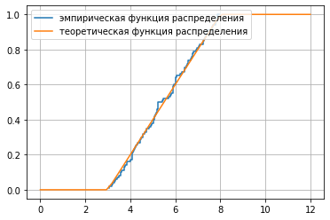

```python
#генерация вборки равномерного распределения
n = 100
x_n = np.random.uniform(low = 3, high = 8, size = n)
#график эмпирической функции распределения
ecdf =  ECDF(x_n)
plt.step(ecdf.x, ecdf.y, label = 'эмпирическая функция распределения')
plt.grid(True)
#график теоретической функции распределения
x = np.linspace(0, 12, 50)
F_x = sts.uniform(3, 5).cdf(x)
plt.plot(x, F_x, label = 'теоретическая функция распределения')
plt.legend(loc = 'upper left')
plt.show()
```

```
Ряд распределения группированной выборки
zk 	 	 	 nk
3.058234713531931 	 0.1437164841401088
3.5453047975158754 	 0.18477833675156843
4.03237488149982 	 0.2669020419744878
4.519444965483764 	 0.1642474104458386
5.006515049467708 	 0.2874329682802176
5.493585133451653 	 0.16424741044583832
5.980655217435598 	 0.20530926305729827
6.467725301419542 	 0.20530926305729827
6.954795385403487 	 0.2258401893630281
7.441865469387431 	 0.20530926305729827
Максимальное отклонение от плотности: 0.10628351585989121
```

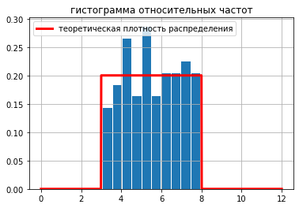

```python
#гистограмма относительных частот
nk_zk = plt.hist(x_n, bins = 10, edgecolor = 'white', density = True)
nk = np.array(nk_zk[0])
zk = np.array(nk_zk[1])
print('Ряд распределения группированной выборки')
print('zk \t \t \t nk')
for i in range(np.size(nk)):
    print(zk[i], '\t', nk[i])
plt.grid(True)
plt.title('гистограмма относительных частот')
#график теоретической плотности распределения
xx = np.linspace(0, 12, 1000)
f_xx = sts.uniform(3, 5).pdf(xx)
plt.plot(xx, f_xx, lw = 3, color = 'r', label = \
         'теоретическая плотность распределения')
plt.legend(loc = 'upper left')
plt.grid(True)
#качество оценки плотности распределения гистограммой
d = np.max(np.abs(nk - 0.25))
print('Максимальное отклонение от плотности:', d)
```

$\newline$

$\newline$

# Часть 3.5. Задания для самостоятельного выполнения

## Задание 1:

Сгенерируйте выборки объемов 20, 50, 200, 1000 нормально распределенной случайной величины X ~ N(m, $\sigma$) (параметры m $\sigma$ выберите самостоятельно) и для каждой из них постройте гистограмму относительных частот и график теоретической плотности распределения. При построении гистограмм используйте одно и то же правило выбора интервалов группировки (любое). Какие закономерности можно подметить? Иллюстрацией какого теоретического утверждения служат полученные рисунки?

## Решение:

Для того чтобы сократить код, введем массив из размеров и будем последовательно выполнять действия с каждой выборокой с помощью цикла for

```
Ряд распределения группированной выборки, n = 20
zk 	 	 	 nk
-5.15037996705905 	 0.017715993258519993
-2.3280713744570543 	 0.08857996629259997
0.49423721814494126 	 0.08857996629259997
3.3165458107469368 	 0.10629595955111995
6.138854403348932 	 0.03543198651703998
8.961162995950929 	 0.017715993258520003
Ряд распределения группированной выборки, n = 50
zk 	 	 	 nk
-7.566597286738315 	 0.016539300572958725
-5.148115330772242 	 0.02480895085943808
-2.729633374806169 	 0.10750545372423166
-0.3111514188400957 	 0.09923580343775235
2.1073305371259767 	 0.07442685257831426
4.525812493092049 	 0.06615720229183485
6.944294449058123 	 0.024808950859438086
Ряд распределения группированной выборки, n = 200
zk 	 	 	 nk
-7.214067000903269 	 0.018074419265836313
-5.55426263547588 	 0.027111628898754472
-3.8944582700484927 	 0.03614883853167263
-2.234653904621105 	 0.07832248348529068
-0.5748495391937167 	 0.07229767706334525
1.0849548262336715 	 0.11145891880599064
2.7447591916610588 	 0.11447132201696325
4.404563557088448 	 0.05723566100848169
6.064367922515835 	 0.033136435320699924
7.724172287943222 	 0.03313643532069989
9.383976653370611 	 0.021086822476809042
Ряд распределения группированной выборки, n = 1000
zk 	 	 	 nk
-11.79222737905853 	 0.0018190455385397384
-10.692749681757162 	 0.0009095227692698677
-9.593271984455791 	 0.0009095227692698692
-8.493794287154422 	 0.005457136615619211
-7.3943165898530525 	 0.007276182154158948
-6.294838892551683 	 0.015461887077587775
-5.195361195250314 	 0.017280932616127502
-4.095883497948944 	 0.04820470677130303
-2.9964058006475742 	 0.05729993446400176
-1.8969281033462053 	 0.06275707107962088
-0.7974504060448346 	 0.08731418584990745
0.30202729125653427 	 0.08185704923428823
1.4015049885579032 	 0.10823320954311426
2.500982685859274 	 0.097318936311876
3.6004603831606428 	 0.07458086708012926
4.699938080462012 	 0.07185229877231954
5.799415777763382 	 0.05457136615619206
6.898893475064753 	 0.050023752309842885
7.99837117236612 	 0.030923774155175502
9.09784886966749 	 0.016371409846857615
10.197326566968862 	 0.009095227692698707
11.296804264270229 	 0.0018190455385397354
12.3962819615716 	 0.0045476138463493385
13.49575965887297 	 0.0036380910770794825
```

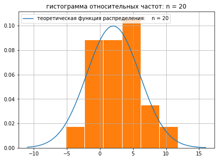

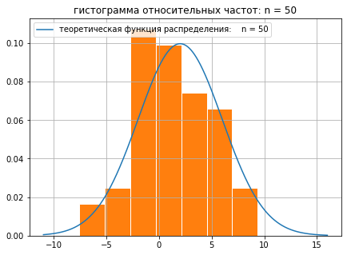

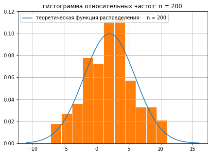

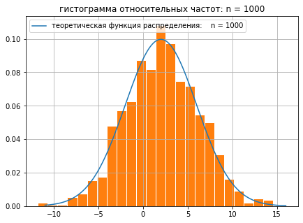

```python
ns = [20, 50, 200, 1000]
Loc = 2
Scale = 4
for n in ns:
    #генерируем выборку нормального распределения
    x_n = np.random.normal(Loc, Scale, n)
    #строим график теоретической плотности распределения
    x = np.linspace(-(Loc+Scale) - 5, Loc + Scale + 10, 1000)
    F_x = (sts.norm(Loc, Scale)).pdf(x)
    plt.figure(figsize = (7, 5))
    plt.plot(x, F_x, label = f'теоретическая функция распределения:\
    n = {n}')
    plt.legend(loc = 'upper left')
    plt.grid(True)

    #cтроим гистограмму относительных частот
    nk_zk = plt.hist(x_n, bins = 'auto', edgecolor = 'white', \
                     density = True)
    plt.title(f'гистограмма относительных частот: n = {n}')

    nk = np.array(nk_zk[0])
    zk = np.array(nk_zk[1])
    print(f'Ряд распределения группированной выборки, n = {n}')
    print('zk \t \t \t nk')
    for i in range(np.size(nk)):
        print(zk[i], '\t', nk[i])
```

Можно заметить что при увеличении объёма выборки гистограмма более точно повторяет площадь под графиком закона распределения. К тому же при увеличении размера выборки увеличивается количество интервалов.

$\newline$

## Задание 2: Используя метод обратных функций, сформируйте несколько выборок (разных объемов) случайной величины X, распределенной по показательному закону с параметром $\lambda$.

Для каждой выборки постройте график эмпирической функции распределения и теоретической функции распределения величины X (в одной системе координат). Прокомментируйте полученные рисунки.

## Решение:

Пусть параметр показательного закона $\lambda$ равен 3. Сформируем выборки объёмов 50, 100, 200, 400, 800, 1000 и 3000. Для того чтобы создать выборку с помощью метода обратных функций мы сформируем выборку заданного объема для случайной величины Y, распределённой равномерно на отрезке [0, 1] и найдем выборочные значения случайной величины X с помощью формулы: $$X = F^{-1}(Y)$$ В данном случае: $$1 - e^{-\lambda \cdot X} = Y \newline X = - \frac{\ln(1 - Y)}{\lambda}$$

Для того чтобы составить эмпирическую функцию распределения, воспользуемся функцией EDCF() и для её построения воспользуемся функцией plt.step(). Чтобы построить график теоретической функции распределения, воспользуемся функцией R.cdf()(здесь R - заданное распределение)

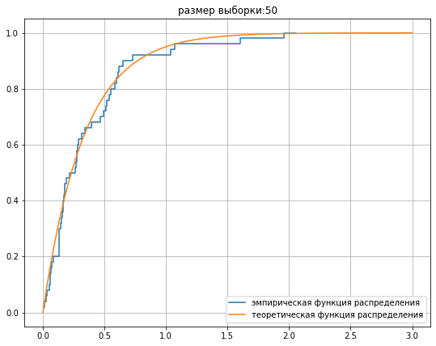

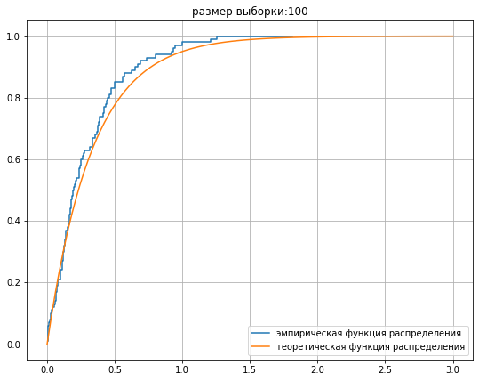

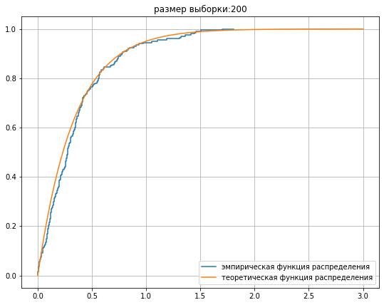

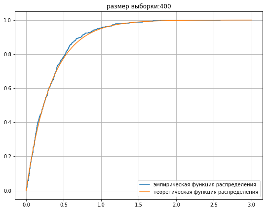

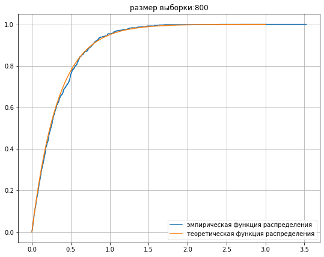

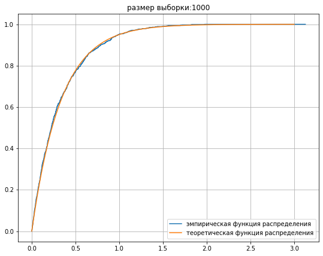

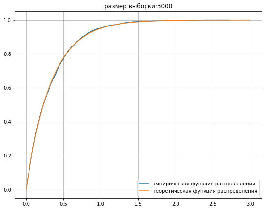

```python
SIZES = [50, 100, 200, 400, 800, 1000, 3000]
Lambda = 3
for SIZE in SIZES:
    Y = np.random.uniform(low = 0.0, high = 1.0, size = SIZE)
    X = []
    for y in Y:
        x = -np.log(1 - y)/Lambda
        X.append(x)
    #график эмпирической функции распределения
    plt.figure(figsize = (9, 7))
    ecdf =  ECDF(X)
    plt.step(ecdf.x, ecdf.y, label = 'эмпирическая функция распределения')
    plt.grid(True)
    #график теоретической функции распределения
    x = np.linspace(0, 3, 100)
    F_x = sts.expon(0, 1/Lambda).cdf(x)
    plt.plot(x, F_x, label = 'теоретическая функция распределения')
    plt.legend(loc = 'lower right')
    plt.title(f'размер выборки:{SIZE}')
    plt.show()
```

Из графиков видно что чем больше объём выборки, тем сильнее эмпирическая функции распределения приближается к теоретической функции распределения

$\newline$

## Задание 3: Сгенерируйте выборку объема 100 случайной величины X , распределенной по показательному закону с параметром $\lambda$ (значение параметра выберите самостоятельно).

Рассчитайте число интервалов группировки по различным правилам (квадратного корня, Райса, Стерджесса, Скотта и Фридмана – Диакониса). Для каждого случая оцените качество представления теоретической плотности распределения гистограммой (в качестве показателя оценки возьмите максимальное по модулю отклонение гистограммы от теоретической плотности). Для какого правила получился лучший по точности результат? Расставьте правила «по рейтингу» точности. Сгенерируйте несколько новых выборок и повторите расчеты. Можно ли сказать, что рейтинг устойчив?

## Решение:

```
РАЗМЕР ВЫБОРКИ - 100

k1 =  10
nk = [3.79278175 2.5950612  1.49715069 0.59886028 0.29943014 0.19962009
 0.59886028 0.09981005 0.         0.29943014]
zk = [1.84430745e-04 1.00374746e-01 2.00565061e-01 3.00755377e-01
 4.00945692e-01 5.01136007e-01 6.01326323e-01 7.01516638e-01
 8.01706953e-01 9.01897269e-01]
Максимальное отклонение от плотности,     число интервалов = 10:  1.20260960201517

k2 =  10
nk = [3.79278175 2.5950612  1.49715069 0.59886028 0.29943014 0.19962009
 0.59886028 0.09981005 0.         0.29943014]
zk = [1.84430745e-04 1.00374746e-01 2.00565061e-01 3.00755377e-01
 4.00945692e-01 5.01136007e-01 6.01326323e-01 7.01516638e-01
 8.01706953e-01 9.01897269e-01]
Максимальное отклонение от плотности,     число интервалов = 10:  1.20260960201517

k3 =  8
nk = [3.6730097  1.99620092 1.11787252 0.23954411 0.31939215 0.31939215
 0.07984804 0.23954411]
zk = [1.84430745e-04 1.25422325e-01 2.50660219e-01 3.75898113e-01
 5.01136007e-01 6.26373902e-01 7.51611796e-01 8.76849690e-01]
Максимальное отклонение от плотности,     число интервалов = 8:  1.3223816574246543

k4 =  6
nk = [3.29373152 1.7366948  0.23954411 0.35931617 0.17965808 0.17965808]
zk = [1.84430745e-04 1.67168290e-01 3.34152149e-01 5.01136007e-01
 6.68119866e-01 8.35103725e-01]
Максимальное отклонение от плотности,     число интервалов = 6:  1.7016598328880206

k5 =  11
nk = [4.06226888 2.63498522 1.31749261 1.31749261 0.2195821  0.32937315
 0.32937315 0.32937315 0.10979105 0.         0.32937315]
zk = [1.84430745e-04 9.12665356e-02 1.82348640e-01 2.73430745e-01
 3.64512850e-01 4.55594955e-01 5.46677060e-01 6.37759165e-01
 7.28841270e-01 8.19923374e-01 9.11005479e-01]
Максимальное отклонение от плотности,     число интервалов = 11:  0.9331224773438302
```

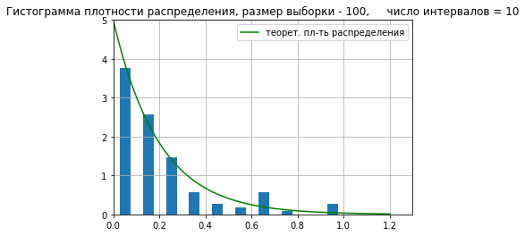

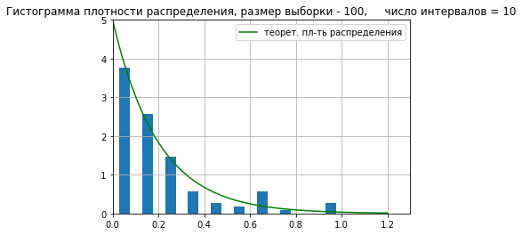

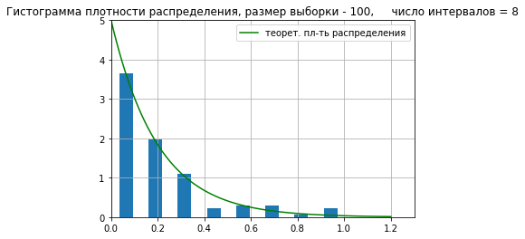

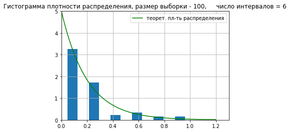

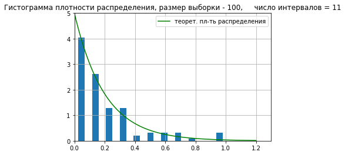

```python
L = 5
Size = 100
print(f'РАЗМЕР ВЫБОРКИ - {Size}\n')
X = np.random.exponential(scale = 1/L, size = Size)
rules = ['sqrt', 'rice', 'sturges', 'scott', 'fd']

for i in range(len(rules)):
    #строим гистограмму и находим число интервалов
    plt.figure()
    nk_zk = plt.hist(X, bins = rules[i], edgecolor = 'white', \
                     density = True, rwidth = 0.5)
    nk = np.array(nk_zk[0])
    zk = np.array(nk_zk[1])
    zk = zk[:len(nk)]
    amt = np.size(zk)

    plt.title(f'Гистограмма плотности распределения, размер выборки - {Size}, \
    число интервалов = {amt}')
    plt.grid(True)
    plt.axis([0, 1.3, 0, 5])

    print(f'k{i + 1} = ', amt)
    print('nk =', nk)
    print('zk =', zk)

    #строим график теоретической плотности распределения
    x = np.linspace(0, 1.2, 100)
    f_x = L*np.exp(-L*x)
    plt.plot(x, f_x, color = 'g', label = 'теорет. пл-ть распределения')
    plt.legend()

    #находим отклонения
    otkls = []
    for j in range(len(zk)):
        otkls.append(np.abs(nk[j] - L*np.exp(-L*zk[j])))
    max_otkl = max(otkls)
    print(f'Максимальное отклонение от плотности, \
    число интервалов = {amt}: ', max_otkl, '\n')
```

В этом случае правила по рейтингу точности можно расставить следующим образом:

1. Правило Фридмана – Диакониса
2. Правило квадратного корня, правило Райса
3. Правило Стреджесса
4. Правило Скотта

Теперь возмём выборки объёма 50 и 80

```
РАЗМЕР ВЫБОРКИ - 50

k1 =  8
nk = [4.00884223 1.68793357 1.68793357 1.68793357 0.2109917  0.42198339
 0.42198339 0.42198339]
zk = [0.00092279 0.09571325 0.19050371 0.28529417 0.38008463 0.47487509
 0.56966555 0.66445601]
Максимальное отклонение от плотности, число интервалов =     8:  1.410422450740777

k2 =  8
nk = [4.00884223 1.68793357 1.68793357 1.68793357 0.2109917  0.42198339
 0.42198339 0.42198339]
zk = [0.00092279 0.09571325 0.19050371 0.28529417 0.38008463 0.47487509
 0.56966555 0.66445601]
Максимальное отклонение от плотности, число интервалов =     8:  1.410422450740777

k3 =  7
nk = [3.50773695 2.03079508 1.66155961 0.73847094 0.36923547 0.5538532
 0.36923547]
zk = [0.00092279 0.10925475 0.2175867  0.32591865 0.43425061 0.54258256
 0.65091452]
Максимальное отклонение от плотности, число интервалов =     7:  1.4692464072596478

k4 =  5
nk = [2.90113582 1.97804715 0.92308867 0.39560943 0.39560943]
zk = [0.00092279 0.15258753 0.30425226 0.455917   0.60758174]
Максимальное отклонение от плотности, число интервалов =     5:  2.075847534261151

k5 =  6
nk = [3.32311922 1.58243772 1.89892527 0.15824377 0.63297509 0.31648754]
zk = [0.00092279 0.12731007 0.25369735 0.38008463 0.50647191 0.63285919]
Максимальное отклонение от плотности, число интервалов =     6:  1.6538641415644535
```

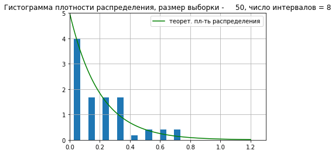

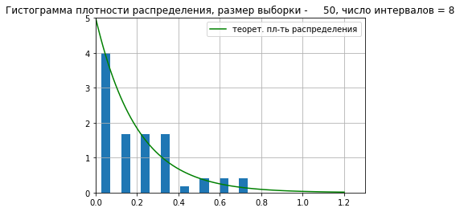

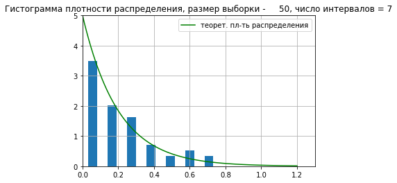

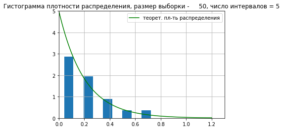

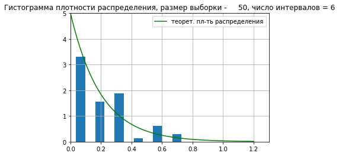

```python
L = 5
Size = 50
print(f'РАЗМЕР ВЫБОРКИ - {Size}\n')
X = np.random.exponential(scale = 1/L, size = Size)
rules = ['sqrt', 'rice', 'sturges', 'scott', 'fd']

for i in range(len(rules)):
    #строим гистограмму и находим число интервалов
    plt.figure()
    nk_zk = plt.hist(X, bins = rules[i], edgecolor = 'white',\
                     density = True, rwidth = 0.5)
    nk = np.array(nk_zk[0])
    zk = np.array(nk_zk[1])
    zk = zk[:len(nk)]
    amt = np.size(zk)

    plt.title(f'Гистограмма плотности распределения, размер выборки - \
    {Size}, число интервалов = {amt}')
    plt.grid(True)
    plt.axis([0, 1.3, 0, 5])

    print(f'k{i + 1} = ', amt)
    print('nk =', nk)
    print('zk =', zk)

    #строим график теоретической плотности распределения
    x = np.linspace(0, 1.2, 100)
    f_x = L*np.exp(-L*x)
    plt.plot(x, f_x, color = 'g', label = 'теорет. пл-ть распределения')
    plt.legend()

    #находим отклонения
    otkls = []
    for j in range(len(zk)):
        otkls.append(np.abs(nk[j] - L*np.exp(-L*zk[j])))
    max_otkl = max(otkls)
    print(f'Максимальное отклонение от плотности, число интервалов = \
    {amt}: ', max_otkl, '\n')
```

В случае с выборкой объёма 50 правила по рейтингу точности можно расставить следующим образом:

1. Правило квадратного корня, правило Райса
2. Правило Стреджесса
3. Правило Фридмана – Диакониса
4. Правило Скотта

```
РАЗМЕР ВЫБОРКИ - 80

k1 =  9
nk = [4.43449557 2.28059772 1.14029886 0.88689911 0.25339975 0.38009962
 0.50679949 0.         0.25339975]
zk = [7.90899724e-05 9.87374364e-02 1.97395783e-01 2.96054129e-01
 3.94712476e-01 4.93370822e-01 5.92029169e-01 6.90687515e-01
 7.89345862e-01]
Максимальное отклонение от плотности, число интервалов =     9:  0.7712607219058505

k2 =  9
nk = [4.43449557 2.28059772 1.14029886 0.88689911 0.25339975 0.38009962
 0.50679949 0.         0.25339975]
zk = [7.90899724e-05 9.87374364e-02 1.97395783e-01 2.96054129e-01
 3.94712476e-01 4.93370822e-01 5.92029169e-01 6.90687515e-01
 7.89345862e-01]
Максимальное отклонение от плотности, число интервалов =     9:  0.7712607219058505

k3 =  8
nk = [4.05439595 1.91457586 1.46408743 0.45048844 0.45048844 0.33786633
 0.11262211 0.22524422]
zk = [7.90899724e-05 1.11069730e-01 2.22060370e-01 3.33051009e-01
 4.44041649e-01 5.55032289e-01 6.66022929e-01 7.77013568e-01]
Максимальное отклонение от плотности, число интервалов =     8:  0.9547848689563452

k4 =  6
nk = [3.96992936 1.26699873 0.67573266 0.33786633 0.33786633 0.16893316]
zk = [7.90899724e-05 1.48066610e-01 2.96054129e-01 4.44041649e-01
 5.92029169e-01 7.40016688e-01]
Максимальное отклонение от плотности, число интервалов =     6:  1.1177764665898458

k5 =  9
nk = [4.43449557 2.28059772 1.14029886 0.88689911 0.25339975 0.38009962
 0.50679949 0.         0.25339975]
zk = [7.90899724e-05 9.87374364e-02 1.97395783e-01 2.96054129e-01
 3.94712476e-01 4.93370822e-01 5.92029169e-01 6.90687515e-01
 7.89345862e-01]
Максимальное отклонение от плотности, число интервалов =     9:  0.7712607219058505
```

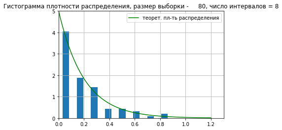

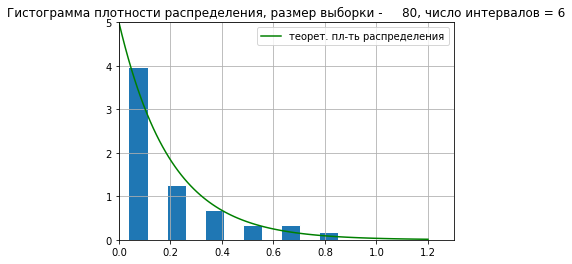

```python
L = 5
Size = 80
print(f'РАЗМЕР ВЫБОРКИ - {Size}\n')
X = np.random.exponential(scale = 1/L, size = Size)
rules = ['sqrt', 'rice', 'sturges', 'scott', 'fd']

for i in range(len(rules)):
    #строим гистограмму и находим число интервалов
    plt.figure()
    nk_zk = plt.hist(X, bins = rules[i], edgecolor = 'white', \
                     density = True, rwidth = 0.5)
    nk = np.array(nk_zk[0])
    zk = np.array(nk_zk[1])
    zk = zk[:len(nk)]
    amt = np.size(zk)

    plt.title(f'Гистограмма плотности распределения, размер выборки - \
    {Size}, число интервалов = {amt}')
    plt.grid(True)
    plt.axis([0, 1.3, 0, 5])

    print(f'k{i + 1} = ', amt)
    print('nk =', nk)
    print('zk =', zk)

    #строим график теоретической плотности распределения
    x = np.linspace(0, 1.2, 100)
    f_x = L*np.exp(-L*x)
    plt.plot(x, f_x, color = 'g', label = 'теорет. пл-ть распределения')
    plt.legend()

    #находим отклонения
    otkls = []
    for j in range(len(zk)):
        otkls.append(np.abs(nk[j] - L*np.exp(-L*zk[j])))
    max_otkl = max(otkls)
    print(f'Максимальное отклонение от плотности, число интервалов = \
    {amt}: ', max_otkl, '\n')
```

[output not shown]

В случае с выборкой объёма 80 правила по рейтингу точности можно расставить следующим образом:

1. Правило Фридмана – Диакониса, правило квадратного корня, правило Райса
2. Правило Стреджесса
3. Правило Скотта